# Incarceration Trends In the U.S. (1970-2018)

Allison Huang

Autumn 2022

## Abstract

**Incarceration rates** across the U.S. give *insight* to more than just jail populations alone, but how they relate to **discriminatory factors** and changing policies. The dataset points to *intersections* between jail populations, and the backgrounds and **identities** of people affected. Additionally, the data reveals trends over time, and how numbers are distributed geographically.

## Introduction

The incarceration rates across the U.S. over the years reveals a lot about the country, including **social issues** and **inequalities**. Specifically, the data exposes patterns of inequality, including those on one’s *identity and background*, such as age, gender, and race, leading to social issues that have arisen as a result. For example, according to data, Black people are much more likely to be arrested in comparison to White people, suggesting deeper problems within social systems and policies set in place in communities (vera.org). Additionally, people of color and other minorities are much more likely to be incarcerated as well too. Differences in rates could mean those in power created policies that give certain groups advantages and others disadvantages, especially those that are already more vulnerable in society.

**Direct stakeholders** include people living in the U.S. in general. More specifically, the audience are people that are incarcerated, and those in groups disproportionately put into jail, so that it can be taken note of to fight for justice in existing inequalities. **Indirect stakeholders** include journalists, policymakers, and government officials. Journalists would use the data to report to the public about incarceration rates in the United States. Policymakers and government officials would refer to data to attempt to lessen inequalities that exist simply due to people’s backgrounds, and train officials so that people are arrested equally due to the right reasons. With this, the central values that the dataset needs to do is be informative and clear, so that people of all levels can interpret the data, and so that the data can be communicated to be used as power to fight against inequalities that occur.

**Questions** that will be answered in the report relate to growth of jail populations in the U.S., jail population by race, and jail populations distributions across states.  
* How have the overall number of jail populations across the country of the United States changed over time?  
* How does the jail population in different states vary and change over time?  
* How does the jail population of people belonging to different races compare, and what are the trends of those racial populations in jail over time?  
* How do jail populations across the U.S. in different states vary in the year of 2018?

## Data Summary

Over the years, the change in the jail population has been in general quite a steep increase. Specifically, within this dataset, there has been an giant increase of about **617,474** in total jail population from the years of 1970 to 2008. However, the change in jail population has been less in comparison to that, within the most recent ten years of the data (2008-2018), with a slight decrease of about **41,075** in total jail population. To add on, in the most recent year of 2018 in the dataset, the average jail population by state across the U.S. was **14,453**. With that, **CA** was the state with the highest jail population at **76,339**. Additionally, the dataset also reveals inequalities in jail population. For example, over the years certain racial groups have made up on average more of the total jail population than other races have. In this case, the two groups with the highest average jail population per year would be Black people with an average of **161,046**, making up **34%** of the total jail population, and White people with an average of **179,894**, making up **38%** of the total population.

## Growth of the U.S. Prison Population

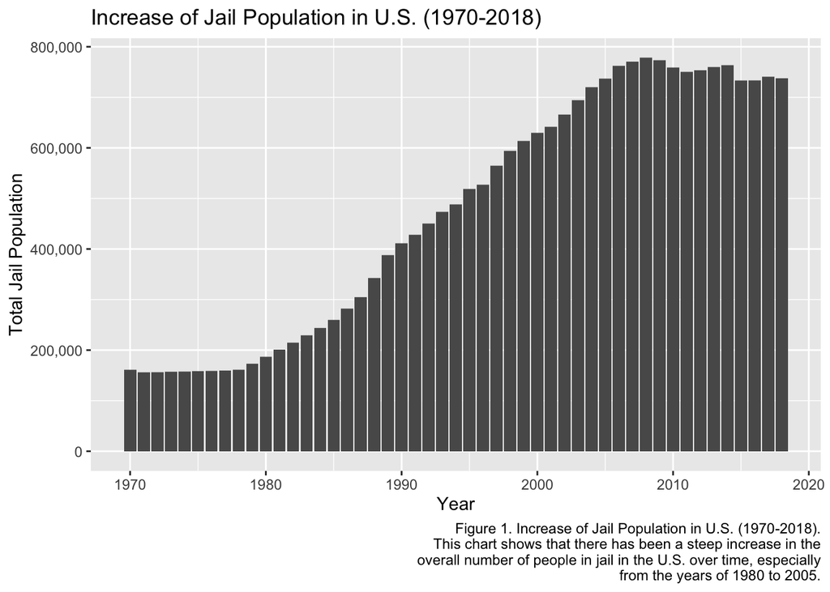

## Growth of Prison Population by State

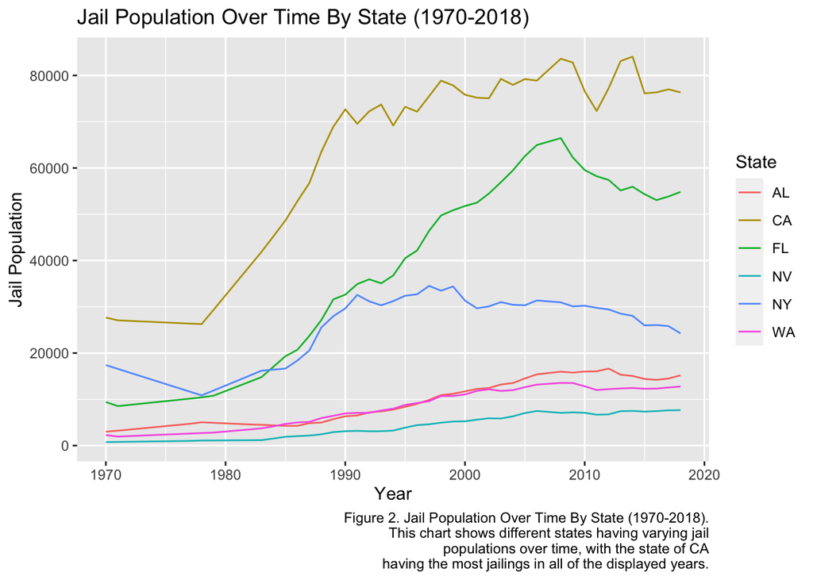

Question: How does the jail population in different states vary and change over time?  
The line graph displays the number of people in jails by state over the time period between 1970 and 2018. From the chart, it can be clearly seen that the state of California has the highest jail populations for all of the years that are included in the data, which could be interesting, as it potentially points to the systems that are put into place in the state of California and specific locations that could be further looked into. In addition, both the states of CA and FL seem to have spikes and jumps in the number of jailings between about 1978 and 2008, in which there were great increases in their respective jail populations. Also, for all of the states that are shown in the chart, they all are depicted to have increases in their state jail populations. The states of AL, CA, FL, NV, NY, and WA were chosen as many of these states are spread out in different sections of the United States. Additionally, there are also a couple states chosen that are next to each other geographically on the US map, for those that want to see how states that are so close in vicinity could also have very different jail populations.

## Prison Population by Race Over Time Reveals Inequality

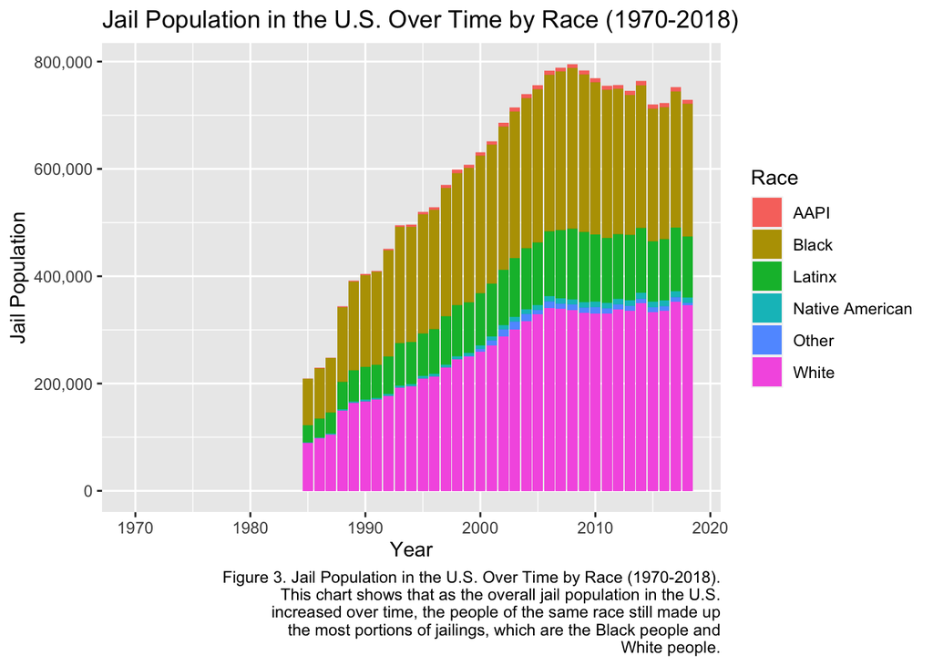

Question: How does the jail population of people belonging to different races compare, and what are the trends of those racial populations in jail over time?  
The graph is significant because it shows groups of people of different racial backgrounds and identities that are disproportionately affected by the jail system, regardless of what the reason may be. It also shows how those trends continue over time, from the 1900s to the present day, therefore signifying that jailings according to race may still be a great issue for politicians and researchers alike to look into. It is interesting to see that over the years, regardless of what the total jail population is, Black people and White people, always seem to have the most people in jail. It is also notable that from the years of 1970 all the way up to nearly 1985, there is no data on the bar chart, as data could not have been compared since the data for some of the races were not available. This is also significant as the data being unavailable could possibly point to the idea that data in regards to race had not been collected at the time, which also points to how times may have potentially changed and people started emphasizing the importance in the disparities between race, which in this case, is the jailing system in the U.S. over time.

## Prison Population By State Reveals Inequality

[figure not shown]